# PML_Project

Archer Lebron

September 24, 2017

# Predicting barbell lift’s exercise performance - How well are people doing it?

In this Coursera’s Practical Machine Learning course project we will analyze exercise data (barbell lifts) of 6 participants to predict how well they did it. In order to do this, we will analyze different variables, and predict the ‘classe’ variable that stands for the performance results of doing the exercise. For this project Cross Validation, and classification prediction statistical method will be employed on a training set to predict 20 observations from a testing data set.

# Data Processing

## Getting the data

Load all the packages to be used in the analysis

```r
library(parallel); library(doParallel); library(caret); library(lattice)
```

```r
library(ggplot2); library(rattle); library(randomForest); library(e1071)
```

Import the training and test data sets for PML course project

```r
pml_training <- read.csv("pml-training.csv", na.string=c("",".","NA"))
pml_testing <- read.csv("pml-testing.csv", na.string=c("", ".","NA"))
```

## Data cleaning

We’ll delete columns that contain missing values in the training and test data sets

```r
training <- pml_training[,colSums(is.na(pml_training)) == 0]
testing <- pml_testing[,colSums(is.na(pml_testing)) == 0]
```

Remove first seven predictors because they don’t have an impact over the outcome `classe`.

```r
trainSubset <- training[,-c(1:7)]
testSubset <- testing[,-c(1:7)]
```

## Data splitting

Splitting the training data set into a new training data set (`newtrain`, 70%) to model fits for prediction on a new testing data set (`newtest`, 30%).

```r
set.seed(8401)
inTrain <- createDataPartition(y=trainSubset$classe, p=0.70, list=FALSE)
newtrain <- trainSubset[inTrain,]
newtest <- trainSubset[-inTrain,]
```

# Fitting Models

For this project we will be applyin classification trees and random forests analysis to predict the outcome (`classe`).

## Random Forests

Create a k=10 k-fold cross validation for our predicting models.

```r
#Configure parallel processing performance improvement
cluster <- makeCluster(detectCores() - 1)
registerDoParallel(cluster)
fitControl <- trainControl(method = "cv", number =10, allowParallel = TRUE)
```

Fit a random forest model using the train() function, with the `newtrain` data set and the `trainControl()` object we created for performance improvement.

```r
rf_fit <- train(classe ~ ., method="rf", data=newtrain, trControl=fitControl)
stopCluster(cluster)
registerDoSEQ()
# Provide details for the random forest model
rf_fit
```

```
## Random Forest
##
## 13737 samples
##    52 predictor
##     5 classes: 'A', 'B', 'C', 'D', 'E'
##
## No pre-processing
## Resampling: Cross-Validated (10 fold)
## Summary of sample sizes: 12364, 12366, 12364, 12364, 12362, 12361, ...
## Resampling results across tuning parameters:
##
##   mtry  Accuracy   Kappa
##    2    0.9927198  0.9907901
##   27    0.9920657  0.9899632
##   52    0.9881355  0.9849912
##
## Accuracy was used to select the optimal model using  the largest value.
## The final value used for the model was mtry = 2.
```

Predict outcome (**classe**) variable using the newtest data set with the Random Forest model fit.

```r
rf_predict <- predict(rf_fit, newdata = newtest)
# Provide overall statistics of accuracy on the random forest predictions
rf_conf <- confusionMatrix(rf_predict, newtest$classe)
rf_conf
```

```
## Confusion Matrix and Statistics
##
##           Reference
## Prediction    A    B    C    D    E
##          A 1670    8    0    0    0
##          B    3 1127   10    0    0
##          C    0    4 1015   14    0
##          D    0    0    1  950    4
##          E    1    0    0    0 1078
##
## Overall Statistics
##
##                Accuracy : 0.9924
##                  95% CI : (0.9898, 0.9944)
##     No Information Rate : 0.2845
##     P-Value [Acc > NIR] : < 2.2e-16
##
##                   Kappa : 0.9903
##  Mcnemar's Test P-Value : NA
##
## Statistics by Class:
##
##                      Class: A Class: B Class: C Class: D Class: E
## Sensitivity            0.9976   0.9895   0.9893   0.9855   0.9963
## Specificity            0.9981   0.9973   0.9963   0.9990   0.9998
## Pos Pred Value         0.9952   0.9886   0.9826   0.9948   0.9991
## Neg Pred Value         0.9990   0.9975   0.9977   0.9972   0.9992
## Prevalence             0.2845   0.1935   0.1743   0.1638   0.1839
## Detection Rate         0.2838   0.1915   0.1725   0.1614   0.1832
## Detection Prevalence   0.2851   0.1937   0.1755   0.1623   0.1833
## Balanced Accuracy      0.9979   0.9934   0.9928   0.9922   0.9980
```

Looking at the Overall Statistics from the Random Forest model, we can see that the Accuracy is 0.9923534.

## Classification Trees

Using the same k-fold cross validation for the Random Forests fit, fit a Classification Trees model.

```r
ct_fit <- train(classe ~., data=newtrain, method="rpart", trControl=fitControl)
ct_fit
```

```
## CART
##
## 13737 samples
##    52 predictor
##     5 classes: 'A', 'B', 'C', 'D', 'E'
##
## No pre-processing
## Resampling: Cross-Validated (10 fold)
## Summary of sample sizes: 12365, 12362, 12363, 12363, 12364, 12365, ...
## Resampling results across tuning parameters:
##
##   cp          Accuracy   Kappa
##   0.02542976  0.5574080  0.43522478
##   0.04239650  0.5070529  0.36352783
##   0.11799410  0.3245276  0.06120022
##
## Accuracy was used to select the optimal model using  the largest value.
## The final value used for the model was cp = 0.02542976.
```

Display Classification Trees visual graph using the fancyRpartPlot function

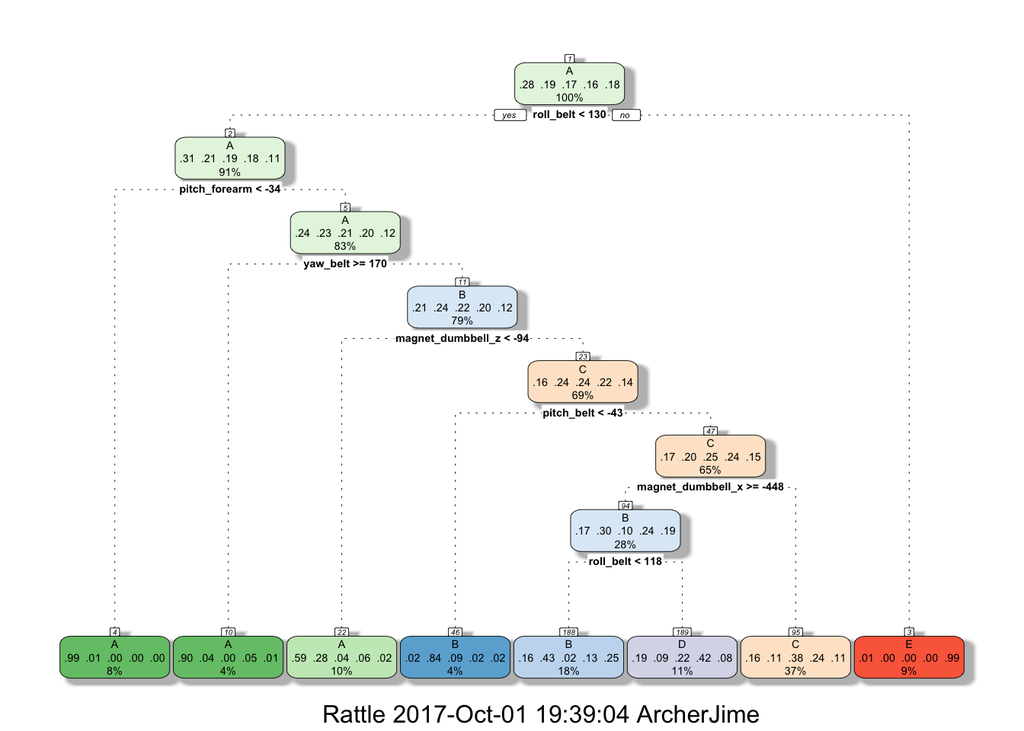

```r
fancyRpartPlot(ct_fit$finalModel)
```

Predict outcome (**classe**) variable using the newtest data set with the Classification Trees model fit.

```r
ct_predict <- predict(ct_fit, newdata=newtest)
# Provide overall statistics of accuracy on the classification trees predictions
ct_conf <- confusionMatrix(ct_predict, newtest$classe)
ct_conf
```

```
## Confusion Matrix and Statistics
##
##           Reference
## Prediction   A   B   C   D   E
##          A 989 169  31  45  15
##          B 182 639  44 137 253
##          C 368 275 807 492 268
##          D 129  56 144 290  83
##          E   6   0   0   0 463
##
## Overall Statistics
##
##                Accuracy : 0.5417
##                  95% CI : (0.5289, 0.5545)
##     No Information Rate : 0.2845
##     P-Value [Acc > NIR] : < 2.2e-16
##
##                   Kappa : 0.4262
##  Mcnemar's Test P-Value : < 2.2e-16
##
## Statistics by Class:
##
##                      Class: A Class: B Class: C Class: D Class: E
## Sensitivity            0.5908   0.5610   0.7865  0.30083  0.42791
## Specificity            0.9383   0.8702   0.7113  0.91628  0.99875
## Pos Pred Value         0.7918   0.5092   0.3652  0.41311  0.98721
## Neg Pred Value         0.8522   0.8920   0.9404  0.86996  0.88571
## Prevalence             0.2845   0.1935   0.1743  0.16381  0.18386
## Detection Rate         0.1681   0.1086   0.1371  0.04928  0.07867
## Detection Prevalence   0.2122   0.2133   0.3755  0.11929  0.07969
## Balanced Accuracy      0.7645   0.7156   0.7489  0.60855  0.71333
```

Looking at the Overall Statistics from the Classification Trees model, we can see that the Accuracy is 0.5417162.

From this analysis we can state that the classification trees model does not preidct the outcome `classe` with high accuracy.

# Making prediction on the Testing data set

Now that we know that the Random Forests model provides a higher accuracy, we will apply this model to predict the oucome `classe` on the original testing data set.

```r
predict_test <- predict(rf_fit, newdata = testing)
predict_test
```

```
##  [1] B A B A A E D B A A B C B A E E A B B B
## Levels: A B C D E
```